# Sampling Distributions & Hypothesis Testing

Lecture 4 - LAS

Don van den Bergh

14-09-2026

## Today

[Chapter 7](https://cjvanlissa.github.io/stats12/samplingdistribution.html) and [Chapter 9](https://cjvanlissa.github.io/stats12/testing.html) from the gitbook.

$$\newcommand{\hypo}{\mathcal{H}}$$

## Learning Goals:

- What are hypotheses?
- What is the logic behind Null Hypothesis Significance Testing (NHST)?
- What is a sampling distribution?
- How do we test hypotheses?
- What is statistical power?

# Hypothesis Testing

## Hypotheses

What are hypotheses?

Examples:

- All swans are white
- A film director’s gender has no impact on whether a movie passes the Bechdel test
- This medicine helps patients recover faster than no medicine

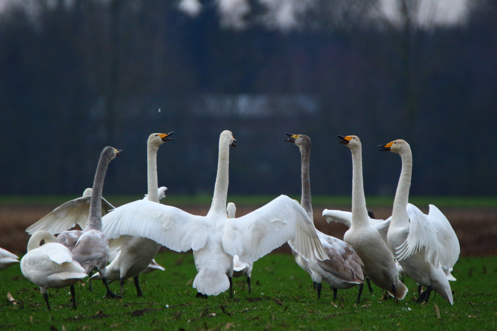

## Falsification

- We typically cannot “confirm” or “validate” hypotheses.
- We can only reject them.
- If we observe 100 white swans, this does not tell us that all swans are white.
- If we observe one black swan, we can reject the hypothesis that all swans are white.

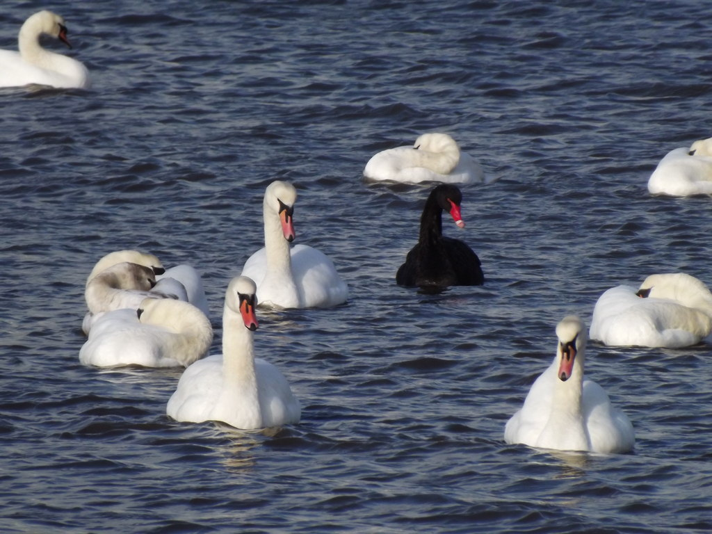

## Falsification - Logic

1. Hypothesis/ Statement: All swans are white
2. Data: A black swan
3. Implication: Not all swans are white
4. Conclusion: Reject the hypothesis

## Falsification - Requirements

A hypothesis must be testable and capable of being proven false.

Is “God exists” a valid hypothesis?

No, because we cannot (scientifically) test the existence of god.

This has nothing to do with whether a claim is true or not. For it to be a hypothesis it must be *testable*.

## Vulcan

[figure not shown]

## From Hypotheses to Theories

Theories are the hypotheses that survive despite serious attempts to refute them.

## Null Hypothesis Significance Testing

In our *sample* we observed that movies with male directors fail the Bechdel test more often than movies with female directors.

But what does this tell us about the population?

|  |  | Director Gender |  |  |
| --- | --- | --- | --- | --- |
| Test | Female | Male | Mixed/other | Total row |
| FAIL | 21 | 957 | 13 | 991 |
| PASS | 94 | 689 | 20 | 803 |
| Total column | 115 | 1646 | 33 | 1794 |

## Null Hypothesis Significance Testing

We expect male and female directors to differ.

But we test the opposite:

- $\hypo_0$: male and female directors pass equally often.
- Assume $\hypo_0$ is true.
- Ask: how surprising are our observed data under $\hypo_0$?
- $p = P(\text{data at least this extreme} \mid \hypo_0)$
- If $p < \alpha$, reject $\hypo_0$.

This is *falsification under uncertainty*.

## Falsification under Uncertainty

There are three options:

1. The data suggest to reject $\hypo_0$
2. The data are not informative to reject or accept $\hypo_0$
3. The data suggest to accept $\hypo_0$

NHST allows us to distinguish **1** from **not 1**:

- $p = P(\text{Data at least this extreme} | \hypo_0)$
- $p < \alpha \rightarrow \text{reject } \hypo_0$.
- $p \geq \alpha \rightarrow \text{do not reject } \hypo_0$.

Failing to reject $\hypo_0$ is not evidence for $\hypo_0$!

## Incorrect Rejections: Error Rates

Even if $\hypo_0$ is true, unusual samples sometimes occur.

$\alpha$ controls how often we are willing to falsely reject $\hypo_0$.

- In the social sciences, usually $\alpha = .05$. When $\hypo_0$ is true, we falsely reject it in 1 out of 20 studies.
- Smaller $\alpha$ demands stronger evidence before rejection.
- For example, physics uses a 5 sigma rule, $\alpha = P(Z>5) = 0.000000287$. A true $\hypo_0$ is falsely rejected in 1 out of 3.5 million studies.

This is a strength of NHST: Sampling uncertainty makes errors unavoidable, but we can control their long-run rate.

## What a $p$-value Does *Not* Tell Us

The logic doesn’t necessarily hold!

- $\hypo_0$: Piet is Dutch.
- Observation: Piet is a member of the Tweede Kamer (parlement).
- $P(\text{Tweede Kamerlid}\mid\text{Dutch})$ is extremely small.
- An NHST-like argument says: That observation would be extremely unlikely if Piet were Dutch, so reject $\hypo_0$.

Yet the observation is obviously evidence for Piet being Dutch rather than against it.

The problem: $P(\text{data}\mid\hypo_0)\neq P(\hypo_0\mid\text{data})$

NHST computes the left-hand side.

## NHST Summary

1. Define $\hypo_0$ and pick $\alpha$.
2. Assume $\hypo_0$ is true.
3. Ask: how surprising are our observed data under $\hypo_0$?
4. $p = P(\text{data at least this extreme} \mid \hypo_0)$
5. If $p < \alpha$, reject $\hypo_0$.

In (3), NHST asks: “how surprising are our observed data if $\hypo_0$ were true?”

But how do we answer that question?

# Sampling Distributions

## Sampling Distributions

Recall the Bechdel-test dataset:

|  |  | Director Gender |  |
| --- | --- | --- | --- |
| Test | Female | Male | Total row |
| FAIL | 21 | 957 | 978 |
| PASS | 94 | 689 | 783 |
| Total column | 115 | 1646 | 1761 |

We observed that female-directed movies fail less often than male-directed movies.

Could a difference this large arise simply because of *sampling variability*?

## Sampling Distributions

Assume the null hypothesis is true:

- $\hypo_0$: Director gender and Bechdel-test outcome are unrelated.

Keep the totals fixed:

- 1761 movies
- 115 female-directed and 1646 male-directed
- 978 FAIL and 783 PASS

Under $\hypo_0$, the 978 FAILs occur randomly across the 1761 movies.

For every hypothetical repetition, record:

- How many of the 115 female-directed movies FAIL?

## Sampling Distributions

If $\hypo_0$ is true, we expect the female-directed movies to have approximately the same failure rate as the complete sample.

The expected number of FAILs is therefore

$$\text{No. Female} \times \frac{\text{No. FAILs}}{\text{No. Movies}} = 115 \times \frac{978}{1761} \approx 63.9.$$

But because of sampling variability, we would not observe exactly 64 every time.

Sometimes we might observe 60, sometimes 70, sometimes 50, …

The distribution of these hypothetical outcomes is a *sampling distribution*.

## Sampling Distributions: Example

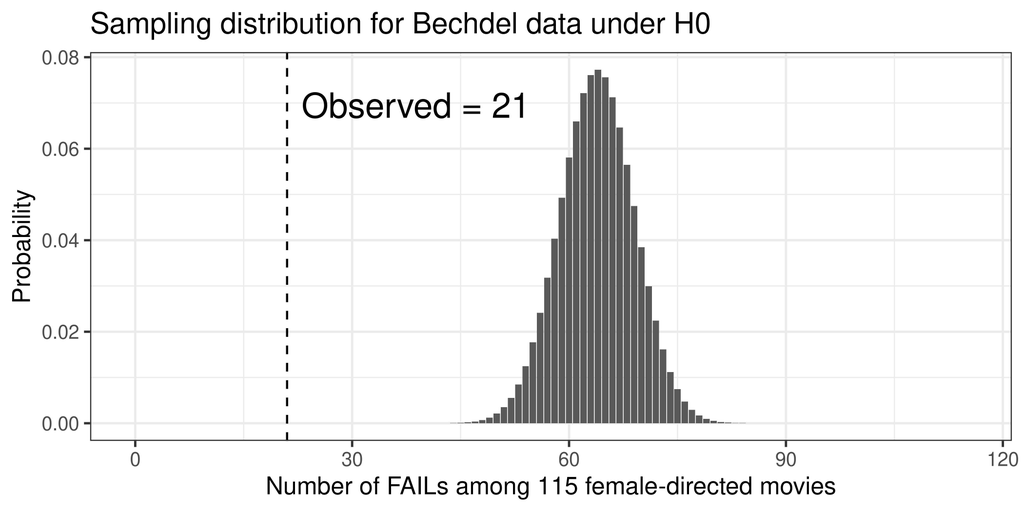

The observed no. FAILs lies far in the tail of the distribution.

## From Sampling Distributions to $p$-values

The $p$-value asks:

> Assuming $\hypo_0$ is true, how probable is a result at least as extreme as the one we observed?

Our observed value was $X_\text{observed} = 21$.

Under $\hypo_0$, observing *21 or fewer* FAILs among female-directed movies has probability $2.38 \times 10^{-17} \approx 0.\underbrace{0000000000000000}_{16 \text{ zeros}}238$

This is very unlikely, if $\hypo_0$ is true.

## Alternative Hypothesis

So far we’ve only stated our null hypothesis.

- $\hypo_0$: Director gender and Bechdel-test outcome are unrelated.
- $\hypo_{1a}$: Director gender and Bechdel-test outcome are related.
  - $P(\text{PASS} | \text{Female}) \neq P(\text{PASS} | \text{Male})$
- $\hypo_{1b}$: Female directors pass the Bechdel-test more often than Male directors
  - $P(\text{PASS} | \text{Female}) > P(\text{PASS} | \text{Male})$

$\hypo_{1a}$ is an *undirected* hypothesis, while $\hypo_{1b}$ is directed.

This matters for the question we ask from the sampling distribution!

## One tailed vs. Two tailed testing

The alternative hypothesis determines the tail area of the sampling distribution.

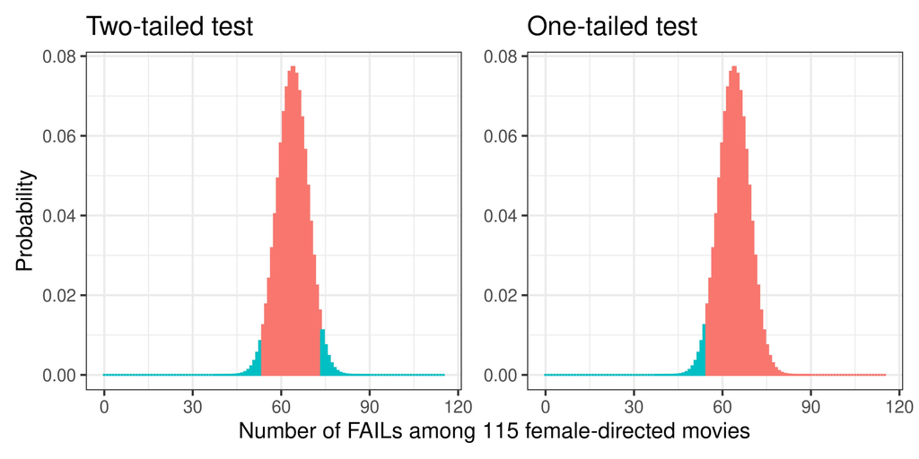

For many symmetric continuous tests, the two-tailed $p$$-value is twice the corresponding one-tailed $p$-value.

## Sampling Distributions

Previous weeks, we observed:

$x_1, x_2, \dots, x_n$

$x_{n+1}, x_{n+2}, \dots, x_{2n}$

$x_{2n+1}, x_{2n+2}, \dots, x_{3n}$

etc.

And eventually the empirical distribution of these $x$ approaches the population distribution, say $\mathcal{N}(\mu, \sigma^2)$.

## Sampling Distributions

Now we examine:

$x_1, x_2, \dots, x_n$, compute $\bar{x}_1$

$x_{n+1}, x_{n+2}, \dots, x_{2n}$, compute $\bar{x}_2$

$x_{2n+1}, x_{2n+2}, \dots, x_{3n}$, compute $\bar{x}_3$

repeat and for each sample $i$, compute the sample mean $\bar{x}_i$.

What is the distribution of $\bar{x}_1, \bar{x}_2, \dots$?

- Each sample mean consists of *finite* observations
- The sampling distribution describes how these behave if we’d repeat this experiment infinitely many times
- We look where our sample statistic falls in this distribution

## Sampling Distributions

In general, the *sampling distribution* is:

> The distribution of a statistic across hypothetical repeated samples from the same population.

Examples of statistics include:

- a proportion
- a correlation
- a sample mean, $\bar{x}$
- a difference between means

For NHST, we care about the sampling distribution *assuming $\hypo_0$ is true*.

## Sampling Distributions

For our Bechdel example, we could derive the sampling distribution exactly.

But suppose instead we observe

$$x_1, x_2, \dots, x_n$$

and are interested in the sample mean

$$\bar{x}.$$

What does the sampling distribution of $\bar{x}$ look like?

Deriving the exact sampling distribution for every possible population distribution would be difficult.

Fortunately, there is a remarkably general result:

# Central Limit Theorem

## Central Limit Theorem

Suppose $x_1, x_2, \dots, x_n \overset{\mathrm{iid}}{\sim} \mathcal{D}(\mu, \sigma^2, \dots)$.

Then, as $n$ becomes large,

$$\bar{x} = \frac{1}{n}\sum_{i=1}^n x_i
\approx \mathcal{N}\left(\mu, \frac{\sigma^2}{n}\right).$$

This holds for all population distributions $\mathcal{D}$, as long as they have a finite mean $\mu$ and variance $\sigma^2$.

Definitions:

- $\overset{\mathrm{iid}}{\sim}$ means *independent* and *identically distributed*.
- *independent*: “knowing the outcome or value of one variable or event provides no information about the probability or outcome of another.”, i.e., observing $x_2$ has no influence on what $x_7$.
- *identically distributed*: All the $x_i$ come from the same population distribution

## Central Limit Theorem

Suppose $x_1, x_2, \dots, x_n \overset{\mathrm{iid}}{\sim} \mathcal{D}(\mu, \sigma^2, \dots)$.

Then, as $n$ becomes large,

$$\bar{x} = \frac{1}{n}\sum_{i=1}^n x_i
\approx \mathcal{N}\left(\mu, \frac{\sigma^2}{n}\right).$$

Here, $\sigma_{\bar{x}} = \frac{\sigma}{\sqrt{n}}$ is known as the *standard error*.

Note that $\sigma_{\bar{x}}$ goes to 0 as n grows.

This indicates that the sample mean converges to the population mean as the no. samples increases.

## The sampling distribution of the mean

σ

Skew

Kurt.

n

Reps

## Why the Central Limit Theorem matters

The impact of $\bar{x} \sim \mathcal{N}\left(\mu, \frac{\sigma^2}{n}\right).$ is huge!

Sums and averages are all around us. For example:

- In educational science, we study at the performance of pupils.
  - Even though grades are scored 1 - 10, we examine the sum, so CLT applies
- fMRI machines’ raw data are voxels (3D pixels) of the brain.
  - Preprocessing steps involve averaging and smoothing the data across multiple voxels. CLT applies.
- We often study proportions, such as the proportion of movies that pass the Bechdel test.
  - Each response can be coded as $x_i = 0$ or $x_i = 1$.
  - The proportion is the average: $\hat{p} = \frac{1}{n}\sum_i x_i$.
  - Therefore, for sufficiently large $n$, $\hat{p}$ is approximately normally distributed.

## Central Limit Theorem – Addendum

Sometimes, we can derive the sampling distribution *exactly*.

Assume $x_1, x_2, \dots, x_n \overset{\mathrm{iid}}{\sim} \mathcal{N}(\mu, \sigma^2)$.

- Then $\frac{\bar X-\mu}{S/\sqrt n} \sim t_{n-1}$.
- But as $n$ tends to $\infty$, $t_{n-1}$ tends to $\mathcal{N}(0,1)$.

So the CLT still applies, but when available we use more precise results for the sampling distribution.

Examples are the $t$-distribution, $F$-distribution, $\chi^2$-distribution.

Some of these we’ll revisit in the second half of the course.

## Sampling Distribution: Summary

Recall NHST:

1. Define $\hypo_0$ and pick $\alpha$.
2. Assume $\hypo_0$ is true.
3. Ask: how surprising are our observed data under $\hypo_0$?
4. $p = P(\text{data at least this extreme} \mid \hypo_0)$
5. If $p < \alpha$, reject $\hypo_0$.
6. The sampling distribution tells us how unusual our observed statistic is under $\hypo_0$
7. The Central Limit Theorem gives a very practical approximation to the sampling distribution

# Statistical Power

## Statistical Power

$\alpha$ is the Type-I error rate: The probability of rejecting a true $\hypo_0$.

$\beta$ is the Type-II error rate: The probability of failing to reject a false $\hypo_0$.

$1 - \beta$ is the power: The probability of rejecting a false $\hypo_0$.

## Statistical Power

|  | $H_0$ false | $H_0$ true |
| --- | --- | --- |
| Reject $H_0$ | Correct rejection / power $1-\beta$ | Type I error $\alpha$ |
| Do not reject $H_0$ | Type II error $\beta$ | Correct non-rejection |

## Statistical Power: Demo

d

n

α

## Statistical Power: Summary

- $\alpha$ is the Type-I error rate: The probability of rejecting a true $\hypo_0$.
- $\beta$ is the Type-II error rate: The probability of failing to reject a false $\hypo_0$.
- power ($1 - \beta$) is the probability of rejecting a false $\hypo_0$.
  - Larger effects are easier to detect.
  - A larger sample size increases the power to detect a given effect.
  - A larger $\alpha$ increases the power, but also increase the type-I error rate.

## Addendum: Contingency test

We only count FAILs among female-directed movies. Why?

If we keep the row and column totals fixed, we have only one unknown:

|  |  | Director Gender |  |
| --- | --- | --- | --- |
| Test | Female | Male | Total row |
| FAIL | $X$ | $978 - X$ | $978$ |
| PASS | $115 - X$ | $783 - (115 - X)$ | $783$ |
| Total column | $115$ | $1646$ | $1761$ |

If $X = 21$, $21$ female-directed movies FAIL, then $978−21=957$ male-directed movies must FAIL.

Thus it does not matter what gender we examine, the results would be identical.